# Course Project ML

ahmedadnane.boutahar@gmail.com

7 mai 2019

# Using devices such as Jawbone Up, Nike FuelBand, and Fitbit it is now possible to collect a large amount of data about personal activity relatively inexpensively. These type of devices are part of the quantified self movement - a group of enthusiasts who take measurements about themselves regularly to improve their health, to find patterns in their behavior, or because they are tech geeks. One thing that people regularly do is quantify how much of a particular activity they do, but they rarely quantify how well they do it. In this project, your goal will be to use data from accelerometers on the belt, forearm, arm, and dumbell of 6 participants. They were asked to perform barbell lifts correctly and incorrectly in 5 different ways. More information is available from the website here: http://groupware.les.inf.puc-rio.br/har (see the section on the Weight Lifting Exercise Dataset).

## Library Import

```r
library(caret)
library(rattle)
library(rpart)
```

```r
library(rpart.plot)
library(RColorBrewer)
library(randomForest)
library(corrplot)
library(gbm)
```

## Dataset

```r
url_training<-"https://d396qusza40orc.cloudfront.net/predmachlearn/pml-training.csv"
url_testing<-"https://d396qusza40orc.cloudfront.net/predmachlearn/pml-testing.csv"
Training_Data <- read.csv(url_training,header=TRUE)
Testing_Data <- read.csv(url_testing,header=TRUE)
dim(Training_Data)
```

```
## [1] 19622   160
```

```r
dim(Testing_Data)
```

```
## [1]  20 160
```

## Clean-up

```r
Training_Data_valid<- Training_Data[, colSums(is.na(Training_Data)) == 0]
Training_Data_valid<-Training_Data_valid[,-c(1:7)]
Testing_Data_valid<- Testing_Data[, colSums(is.na(Training_Data)) == 0]
Testing_Data_valid<-Testing_Data_valid[,-c(1:7)]
dim(Training_Data_valid)
```

```
## [1] 19622    86
```

```r
dim(Testing_Data_valid)
```

```
## [1] 20 86
```

## Model Building

```r
set.seed(123)
Train_index<- createDataPartition(Training_Data_valid$classe,p = 0.7,list=FALSE)
training_mod <- Training_Data_valid[Train_index, ]
testing_mod <- Training_Data_valid[-Train_index, ]
training_mod<-training_mod[,-nearZeroVar(training_mod)]
testing_mod<-testing_mod[,-nearZeroVar(testing_mod)]
dim(training_mod)
```

```
## [1] 13737    53
```

```r
dim(testing_mod)
```

```
## [1] 5885   53
```

# in the next sections we will show the results of :

# -rf:Train with random forests

```r
trControl <- trainControl(method="cv", number=5)
Model_rf <- train(classe~.,data=training_mod, method="rf",trControl=trControl, verbose=FALSE)
train_pred_rf <- predict(Model_rf,newdata=testing_mod)
confusion_matrix_rf <- confusionMatrix(testing_mod$classe,train_pred_rf)
confusion_matrix_rf$table
```

```
##           Reference
## Prediction    A    B    C    D    E
##          A 1672    2    0    0    0
##          B    8 1128    2    1    0
##          C    0    8 1015    3    0
##          D    0    0   17  946    1
##          E    0    0    1    1 1080
```

```r
confusion_matrix_rf$overall[1]
```

```
##  Accuracy
## 0.9925234
```

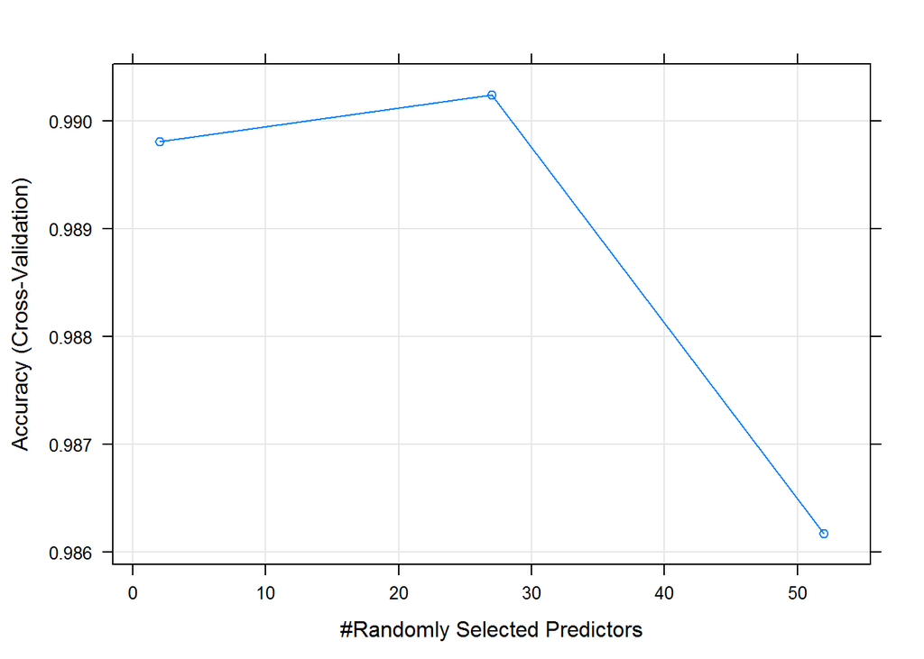

```r
plot(Model_rf)
```

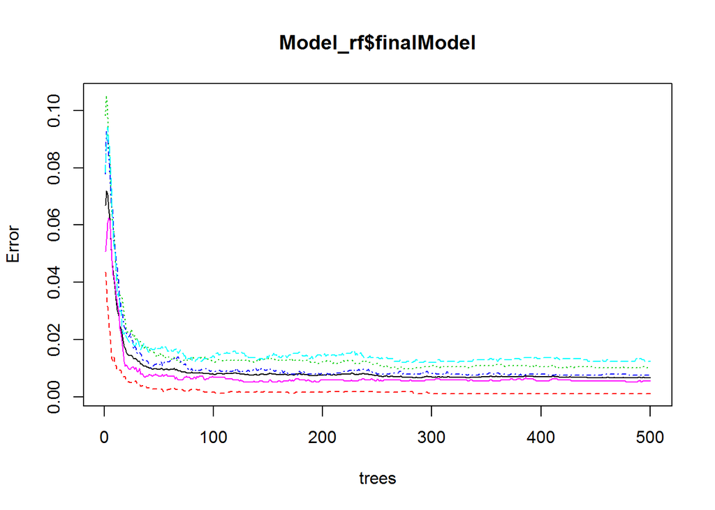

```r
plot(Model_rf$finalModel)
```

##-rpart:Train with classification tree

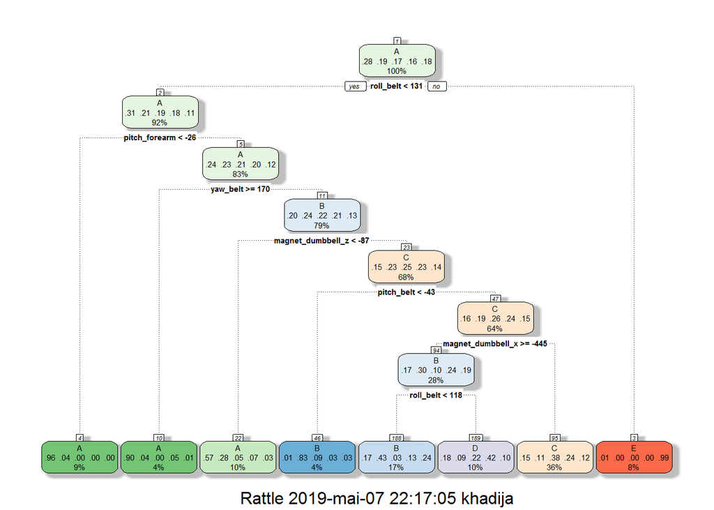

```r
Model_rpart <- train(classe~., data=training_mod, method="rpart")
fancyRpartPlot(Model_rpart$finalModel)
```

```r
train_pred <- predict(Model_rpart,newdata=testing_mod)
confusion_matrix_rpart <- confusionMatrix(testing_mod$classe,train_pred)
confusion_matrix_rpart$table
```

```
##           Reference
## Prediction    A    B    C    D    E
##          A 1061  163  341  102    7
##          B  235  631  230   43    0
##          C   27   42  819  138    0
##          D   64  133  509  258    0
##          E   13  281  247   60  481
```

```r
confusion_matrix_rpart$overall[1]
```

```
##  Accuracy
## 0.5522515
```

# we notice low accuracy

## -GBM:Train with gradient boosting method

```r
model_GBM <- train(classe~., data=training_mod, method="gbm", trControl=trControl, verbose=FALSE)
train_pred_GBM <- predict(model_GBM,newdata=testing_mod)
confusion_matrix_GBM <- confusionMatrix(testing_mod$classe,train_pred_GBM)
confusion_matrix_GBM$table
```

```
##           Reference
## Prediction    A    B    C    D    E
##          A 1642   17   12    2    1
##          B   48 1058   30    3    0
##          C    0   38  971   15    2
##          D    1    0   40  919    4
##          E    6    6    6   13 1051
```

```r
confusion_matrix_GBM$overall[1]
```

```
##  Accuracy
## 0.9585387
```

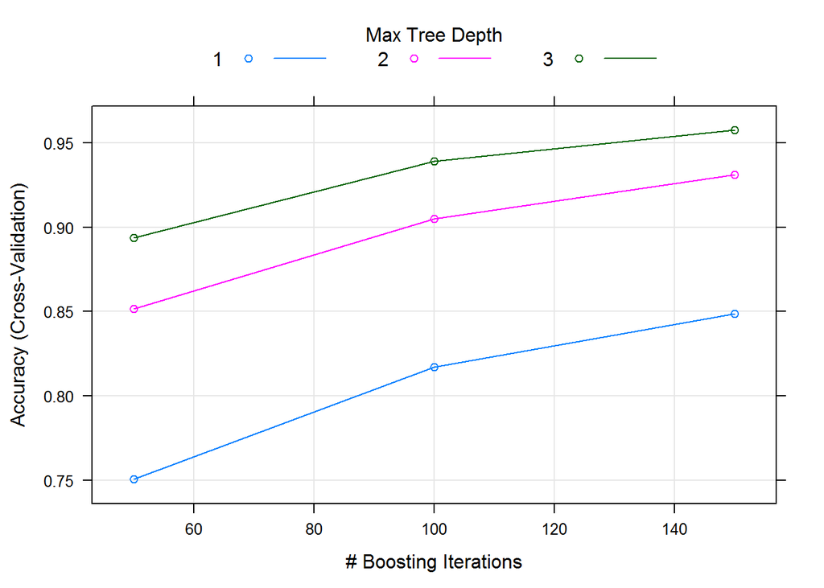

```r
plot(model_GBM)
```

# the Random forest is the best model, which give the better accuracy

```r
Testing_Data_Pred <- predict(Model_rf,newdata=Testing_Data_valid)
Testing_Data_Pred
```

```
##  [1] B A B A A E D B A A B C B A E E A B B B
## Levels: A B C D E
```